# Bayesian regression methods

## Motivation

- mechanistic
- public health
- interactions are difficult to pick up
- consider the number of interactions that would have to be encoded explicitly in MLR
- different types of interactions

## Bayesian kernel machine regression

Defining notation:

- observations from $i = 1, \dots ,n$
- $\textbf{x}_m$ is a predictor variable in the predictor matrix $\textbf{X}$ with $m = 1, \dots, M$, measuring exposure variables in this case
- $\textbf{x}_i$ is a vector of values for a single observation in $\textbf{X}$ with $i = 1, \dots, n$, measuring the health outcome in this case
- $x_{im}$ is an observation of $\textbf{x}_m$
- $Y_i$ is an observation of $\textbf{Y}$
- $\rho$ is the tuning parameter inside the exponential expression of the covariance, equals $2l$
- $\tau$ is the tuning parameter outside the expontential expression of the covariance, equals $\sigma_f^2$
- $k$ is the smoothing function, the Gaussian in this case
- $\textbf{K}$ is the $n \times n$kernel matrix, with (i, j)th element $k(\textbf{x}_i, \textbf{x}_j)$
- $h(\textbf{x}_i)$ the flexible function relating X to Y
- $\boldsymbol\epsilon_i \overset{\mathrm{iid}}{\sim} N(0, \sigma^2)$, the residuals of the response

### Kernel machine regression

In this section, we introduce kernel machine regression, with attention to its specific implementation in BKMR. Kernel machine regression is a nonparametric regression technique that can be used to capture nonlinear effects and nonadditive interactions. In the typical linear regression setting,

$$Y_i = \textbf{x}_i^\top\boldsymbol{\beta} + \epsilon_i$$

where $Y_i$ measures a health outcome at a given point, $\textbf{x}_i = (x_{1},\dots,x_{M})^\top$ is a vector of M exposures, $\boldsymbol{\beta}$ is a vector of weights, and $\epsilon_i$ is a random variable from $\boldsymbol\epsilon \overset{\mathrm{iid}}{\sim} N(0, \sigma^2)$. We can see that this function assumes that there is a linear relationship between the exposure and the response, and that the combined effects of multiple exposures are additive.

Kernel machine regression defines this relationship using a function $h: \mathbb{R}^M \rightarrow \mathbb{R}$, where

$$Y_i = h(\textbf{x}_i) + \epsilon_i$$

Here, $h(\cdot)$ is represented by the function $k(\cdot, \cdot)$, a kernel. The kernel controls the covariance, or the similarity, between values of $h(\textbf{x})$ and as such ensures that points near each other on the prediction surface will have similar values — or, in other words, that the prediction surface will be smooth. In the case of kernel machine regression, we define a positive definite kernel where $k: \mathbb{R}^M\times \mathbb{R}^M \rightarrow \mathbb{R}$. There are many choices of functions to represent $k$. BKMR uses the Gaussian kernel, also known as the radial basis function or, sometimes, the squared exponential kernel. The Gaussian kernel is defined

$$k(\textbf{x}, \textbf{x}') = \sigma_f^2\textrm{exp}\{
-\frac{||\textbf{x}-\textbf{x}'||^2}{2l}\}$$

where $||\textbf{x}-\textbf{x}'||^2 = \sum_{m=1}^M{(x_{m}-x_{m}')^2}$ for $\textbf{x}$, a set of exposure values, and $\textbf{x}$, the exposure profile of a second subject, $\sigma_f^2$ is a tuning parameter that controls how much the function is allowed to vary, and $l$ is a tuning parameter that controls the relationship between the correlation between two points and their distance. Greater values of $l$ will enforce more dependence between points and make the resulting function smoother. Note that BKMR uses $\rho=2l$ and $\tau=\sigma_f^2$, so, henceforth, we will be referring to these parameters using BKMR’s notation.

Now that we have defined $h$ and $k$, we can think about how to characterize the relationship between our response and predictors. Kernel machine regression is a nonparametric technique because it does not specify a functional form for this relationship. Hence, we will think about estimating the response at a particular query point. Operationally, kernel machine regression uses a weighted average of all the observations in the dataset to estimate the response, as follows

$$\bar{Y} = \frac{\sum_{i=1}^nw_iY_i}{\sum_{i=1}^nw_i}$$

with some set of weights $\{w_i\}_{i=1}^n$. Intuitively, we want to weight the observations that are closer to the query point more heavily. Using the Gaussian kernel as a weight allows us to achieve this. Replacing the weight with the Gaussian kernel, we get

$$\bar{Y} = \frac{\sum_{i=1}^n K(\textbf{x}, \textbf{x}_i) Y_i}
{\sum_{i=1}^n K(\textbf{x}, \textbf{x}_i)}$$

As we move through the predictor space, we can think of the prediction as a continuous moving average of local points in the dataset. This gives us the following relationship

$$\textrm{cor}(h_i, h_j) = \textrm{exp}\{-(\frac{1}{\rho}) \sum_{m=1}^M
{(x_{im}-x_{jm})^2}\}$$

which allows us to see that values $h$ near each other will have a higher correlation and thus similar values. This is also why the resulting function is smooth.

### Connection with mixed models

It is useful to make connections between this definition of kernel machine regression and mixed models. To do this, we can represent $h(\textbf{x})$ as following a Gaussian process probability distribution, defined

$$h(\textbf{x}) \sim \mathcal{GP}(\textbf{0}, k(\textbf{x},
\textbf{x}'))$$

with mean function $m$ and covariance function $k$, where $\textbf{x}$ is a vector of exposure values, and $\textbf{x}'$ is the exposure profile of another subject. A Gaussian process is a collection of random variables, of which any finite number follow a multivariate normal distribution. Here, we assume that the expected value of the function with input $\textbf{x}$ is $\textbf{0}$. We use $k$ for the covariance function, whic represents the dependence between the function values with inputs $\textbf{x}$ and $\textbf{x}'$: $k(\textbf{x}, \textbf{x}') = \mathbb{E}[(h(\textbf{x})-m(\textbf{x})) (h(\textbf{x}')-m(\textbf{x}'))]$.

Now, we can represent $h$ as a collection of variables from a Gaussian process. $h$ follows a multivariate normal distribution

$$h({\textbf{x}}) \sim N(\textbf{0}, \textbf{K})$$

where $h({\textbf{x}}) = h(\textbf{x}_1), h(\textbf{x}_2), \dots, h(\textbf{x}_n)$, and $\textbf{K}$ is the kernel matrix. The kernel matrix is an $n \times n$ matrix with $(i, j)$th element $k(\textbf{x}_i, \textbf{x}_j)$. Now, returning back to the regression view, we can think of each $Y_i$ as following the distribution

$$Y_i \overset{\mathrm{ind}}{\sim} N(h(\textbf{x}_i), \sigma^2) \text{ for
} i = 1,\dots,n$$

where $\sigma^2$ comes from the variance of the residuals.

### Toy example

In the following section, we introduce the technique with a toy example.

Consider the following case where we want to model the relationship between a single predictor and a response variable. Suppose the true relationship between x and Y is defined $Y = e^{\frac{x}{10}} + 2\sin(\frac{x}{2})$

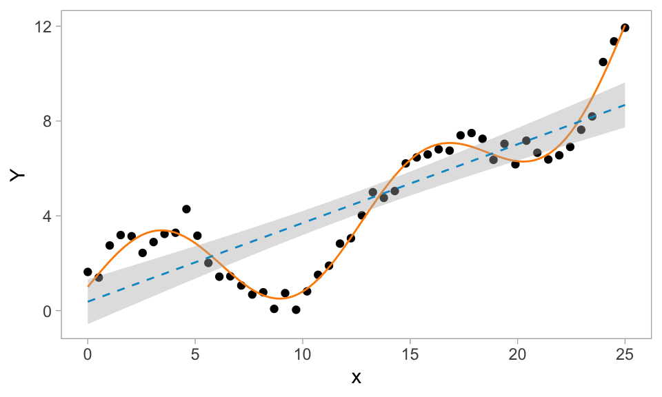

Define a query point

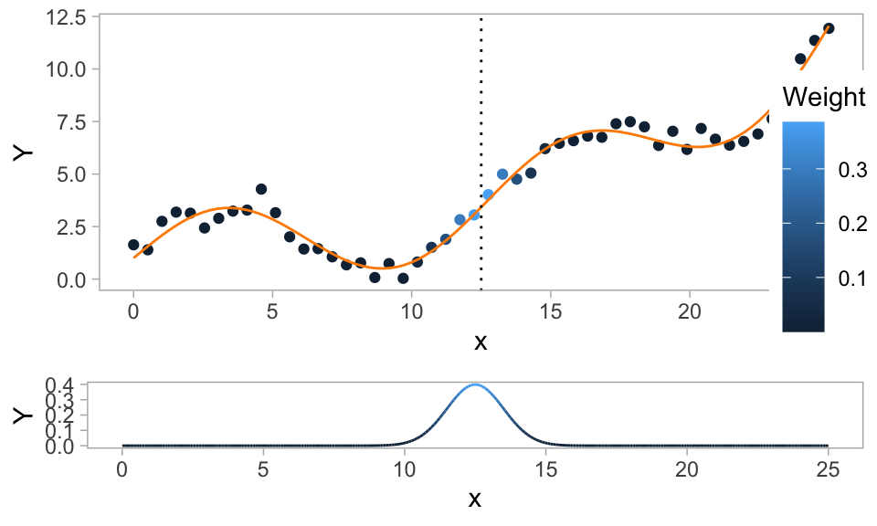

Note to self, bandwidth represent four times the quartiles of the probability density. In the case of a Gaussian kernel, the bandwidth represents $\frac{8}{3}\sigma$, so using an sd of 1 translates to bandwidth of 8/3

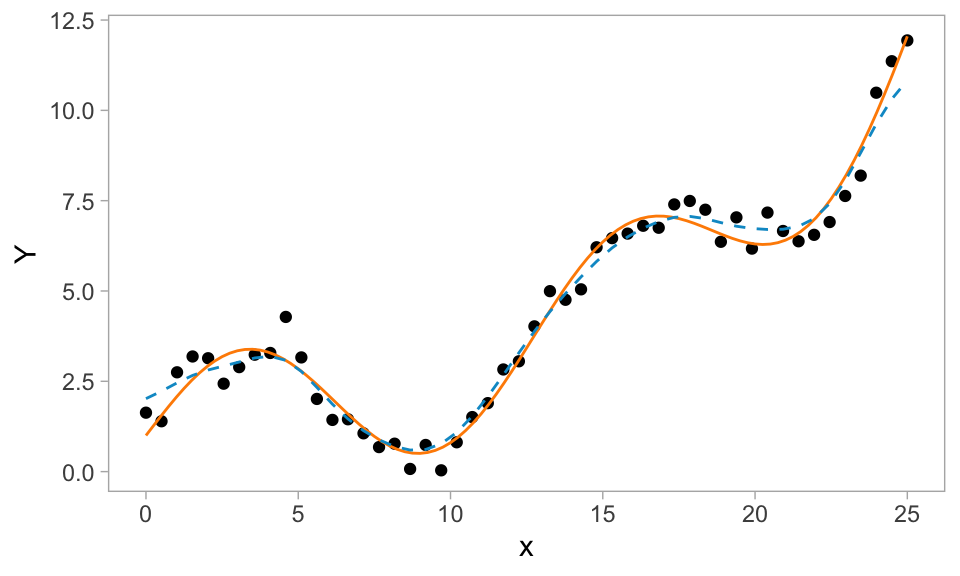

### Priors in a Bayesian framework

## Bayesian semiparametric regression

differences w/ bkmr

- makes distributional assumptions about the dataset
- kernel regression is computationally intensive w/ large datasets

### Connections to linear mixed model

### Toy example

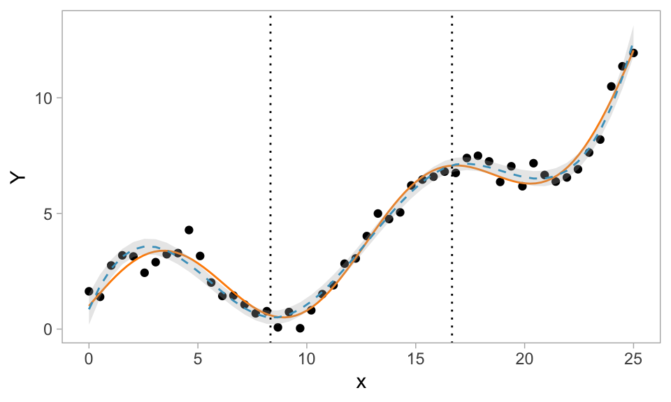